# Assignment 2

Google and Baidu Translation Analysis

Boyang Yan(s3889673) Zehan Sun(s3890335)

Last updated: 23.5.2021

# RPubs link information

- We published our presentation to RPubs (see [**here**](https://rpubs.com/JayciesS/Math1324-as2)) and add this link to your presentation here.

# Introduction

- The purpose of this assessment for using **Hypthesis Testing** to evaluate and compare **Baidu** machine translation and **Google** machine translation. The basic idea is using same sentiment analysis tool analyze both side (origin data and translated data) for determine the quality of translation. The high quality of translation should have less differences and high correlation between original data sentiment score and translated data sentiment score.
- There are two datasets we are used in this research. The **primary dataset** from [**kaggle**](https://www.kaggle.com/yanboyang713/douban-movie-comments-with-on-personal-tailor) which about Movie audience comments with rating and comments on **Personal Tailor** (a 2013 Chinese film), collected from **Douban** (a popular Chinese social media platform).
- Second dataset, include translated data and Sentiment data (translation Origin Comments to translated Comments, after sentiment analysis both sides).
- We used these two data sets and merge them together as a new main data set. However, this is an untidy data set, we reshape the data set into a tidy format.
- We used paired t-test to check the difference of translation tools and Pearson correlation test to compare which tool is better.

# Problem Statement

- In this assignment, we compare Original Comments Score and Translated Comments Score to analyse whether the two translation tool (Google, Baidu) is based on the correctness of the original translation.
- First, we need to exploring the mean, median, max, min, and IQR for original data Sentiment score and translation data Sentiment score from Google and Baidu translation tools, then draw the boxplots to evaluate the difference about original data Sentiment score and translated data Sentiment score for both Baidu and Google data sets.
- Then, we will do the paired t-test to check the difference between the original data Sentiment score and translated data Sentiment score by Baidu or Google translation tools.
- At the last, we would like to check the correlation about original data Sentiment score and translated data Sentiment score by Baidu or Google translation, and compared which translation tools is translated more correlative to original data.

# Data

- The **Origin Movie Comments Dataset**, download from **kaggle**.
- There are **56,860** Movie audience comments (Chinese) with rating, comments and timestap on **Personal Tailor** (a 2013 Chinese film), collected from *Douban* (a Chinese social media platform) ,has been used as the **primary dataset** of this assessment.
- This dataset have three variables:
  - timestamp (Created date of comments and ranking)
  - ranking (Movie audience give this movie a ranking (0, 10, 20, 30, 40, 50))
  - comments (Movie audience write a comment for this movie)
- Load Origin Movie Comments Dataset:

```r
originData <- read.xlsx("./originData.xlsx", sheet = "Sheet 1", colNames = TRUE, detectDates = TRUE)
originData %>% head(3)
```

|  | timestamp | ranking | comments |
| --- | --- | --- | --- |
| 1 | 2013-11-29 | 20 | 关于这部电影最良心的地方就是他没做成3D。 |
| 2 | 2013-12-19 | 10 | 张艺谋当年拍奥运是拿《满城尽带黄金甲》练手，练舞美和艺指；冯小刚今年拍春晚是拿《私人订制》练手，练了仨小品一朗诵，三俗一雅终归一烂。 |
| 3 | 2013-12-17 | 10 | 不想提前剧透，但必须负责任地说，看过《私人定制》，我唯一想做的事就是默默地伸出中指，相信我，这部电影不值得你花任何一分钱走进电影院，用最不真诚的方式咯吱你，被咯吱的这个累啊，然后看你要发飙，又来了一段无厘头的环保公益广告，冯小刚真的达到了成全自己，恶心别人的境界 |

|  | timestamp <date> | ranking <dbl> | comments <chr> |
| --- | --- | --- | --- |
| 1 | 2013-11-29 | 20 | 关于这部电影最良心的地方就是他没做成3D。 |
| 2 | 2013-12-19 | 10 | 张艺谋当年拍奥运是拿《满城尽带黄金甲》练手，练舞美和艺指；冯小刚今年拍春晚是拿《私人订制》练手，练了仨小品一朗诵，三俗一雅终归一烂。 |
| 3 | 2013-12-17 | 10 | 不想提前剧透，但必须负责任地说，看过《私人定制》，我唯一想做的事就是默默地伸出中指，相信我，这部电影不值得你花任何一分钱走进电影院，用最不真诚的方式咯吱你，被咯吱的这个累啊，然后看你要发飙，又来了一段无厘头的环保公益广告，冯小刚真的达到了成全自己，恶心别人的境界 |

3 rows

# Data Cont.

- The second dataset is **Machine Translation and Sentiment Analysis Results Dataset**.
- This data set includes Machine translation data and sentiment data.
- We used **Google translation** and **Baidu translation**, translate **primary dataset**’s chinese movie comments to English comments.
- The data included the translated score and magnitude:
  - **Score** of the sentiment ranges between -1.0(negative) and 1.0(positive) and corresponds to the overall emotional leaning of the text.
  - **Magnitude** indicates the overall strength of emotion (both positive and negative) within the given text, between 0.0 and +inf. However, we are not gonna use this variable for future analyzing.

```r
TranlationAndSentimentResults <- read_csv("TranlationAndSentimentResults.csv")
TranlationAndSentimentResults %>% head(3)
```

| Origin comments data | Google translated data | Baidu translated data | Google Chinese sentiment analysis score (base on Chinese origin data) | Google Chinese sentiment analysis manitude (base on Chinese origin data) | Google English sentiment analysis score (base on Google translated data) | Google English sentiment analysis manitude (base on Google translated data) | Google English sentiment analysis score (base on Baidu translated data) | Google English sentiment analysis manitude (base on Baidu translated data) |
| --- | --- | --- | --- | --- | --- | --- | --- | --- |
| - - | - - | - | 0.1 | 0.1 | 0.1 | 0.1 | 0.1 | 0.1 |
| ！ | ！ | ! | 0.0 | 0.0 | 0.0 | 0.0 | 0.0 | 0.0 |
| ！说不好的什么心态？ | ! What state of mind is not good? | ! What is a bad state of mind? | 0.0 | 0.1 | -0.2 | 0.6 | -0.1 | 0.4 |

| Origin comments data <chr> | Google translated data <chr> | Baidu translated data <chr> | Google Chinese sentiment analysis score (base on Chinese origin data) <dbl> | Google Chinese sentiment analysis manitude (base on Chinese origin data) <dbl> |  |
| --- | --- | --- | --- | --- | --- |
| - - | - - | - | 0.1 | 0.1 |  |
| ！ | ！ | ! | 0.0 | 0.0 |  |
| ！说不好的什么心态？ | ! What state of mind is not good? | ! What is a bad state of mind? | 0.0 | 0.1 |  |

3 rows | 1-5 of 9 columns

# Data Cont.

The second dataset, Boyang write **Python** code for query Google Sentiment Analysis API and Google Machine Translation API and Baidu Machine Translation API

Google Sentiment Analysis API will return one **json** file for each query. In this **json** file, have two values, which are **score** and **manitude**. According to **Each value must have its own cell**, so previously I am already separate this two values into two cells in the same row.

# Data Cont.

- Merge two data set and named **dataset**
- After dataset merged, it includes 56860 observations with 11 variables. The variable **ranking** is numeric variables, and we need to translate this to ordered factor.
- to analysis the data easier, we need **transfer data from wide to long format** for **Machine Translation Results** Data matrix.

```r
#Merge two data set
dataset <- originData %>% left_join(TranlationAndSentimentResults, c("comments" = "Origin comments data"))

#and relabel the "Ranking 0" and "Ranking 10", "Ranking 20", "Ranking 30", "Ranking 40", "Ranking 50"
#in ranking as "0" "10", "20", "30", "40", "50"
dataset$ranking <- dataset$ranking %>% factor(
  levels = c(0,10,20,30,40,50),
  labels = c("Ranking 0","Ranking 10", "Ranking 20", "Ranking 30", "Ranking 40", "Ranking 50"))

#transfer data from wide to long format
dataset <- dataset %>% pivot_longer(names_to = "translationTool", values_to = "tranlatedData", cols = 4:5)
```

# Data Cont.

- we need to reshape the data set to set Baidu and Google translation tool inside one column, and generate the translated data score in one column

```r
# bind translatedDataScore and translatedDataManitude to dataset
dataset <- cbind(dataset, translatedDataScore)
dataset <- cbind(dataset, translatedDataManitude)
```

- We want to each row only relative with one kind of translation tool, but after previously step others translation tool result also is exist. So, we need remove others translated comments sentiment result, only keep the translation tool in used sentiment data.

```r
# remove others translated comments sentiment result
dataset <- dataset[ , ! names(dataset) %in% c("Google English sentiment analysis score (base on Google translated data)", "Google English sentiment analysis manitude (base on Google translated data)", "Google English sentiment analysis score (base on Baidu translated data)", "Google English sentiment analysis manitude (base on Baidu translated data)")]
```

- Change translationtool variable as factor

```r
# translationTool is factor, labels Google and Baidu
dataset$translationTool <- dataset$translationTool %>% factor(
  levels = c("Google translated data", "Baidu translated data"),
  labels = c("Google", "Baidu"))
```

- then change the columns name

```r
# change the col name for OriginCommentsScore and OriginCommentsManitude
colnames(dataset)[4] <- "OriginCommentsScore"
colnames(dataset)[5] <- "OriginCommentsManitude"
```

# Descriptive Statistics and Visualisation

- Comparing the translated data score and original data score in different translation tools with descriptive statistics.
- In translated data score for Google and Baidu, both medians are larger than means, so both groups are Left skewed
- In original data score for Google and Baidu, both medians are smaller than means, so both groups are right skewed

-google translated data score

```r
knitr::kable(tableGoogle_trans)
```

| translationTool | Min | Q1 | Median | Q3 | Max | Mean | SD | n | Missing |
| --- | --- | --- | --- | --- | --- | --- | --- | --- | --- |
| Google | -0.9 | -0.5 | 0 | 0.2 | 0.9 | -0.0896494 | 0.4871084 | 56860 | 7452 |

- baidu translated data score

```r
knitr::kable(tableBaidu_trans)
```

| translationTool | Min | Q1 | Median | Q3 | Max | Mean | SD | n | Missing |
| --- | --- | --- | --- | --- | --- | --- | --- | --- | --- |
| Baidu | -0.9 | -0.4 | 0 | 0.2 | 0.9 | -0.0485589 | 0.4637327 | 56860 | 7452 |

- google original comments score

```r
knitr::kable(tableGoogle_origi)
```

| translationTool | Min | Q1 | Median | Q3 | Max | Mean | SD | n | Missing |
| --- | --- | --- | --- | --- | --- | --- | --- | --- | --- |
| Google | -0.9 | -0.3 | 0 | 0.4 | 0.9 | 0.0534893 | 0.5020233 | 56860 | 7452 |

- baidu original comments score

```r
knitr::kable(tableBaidu_origi)
```

| Min | Q1 | Median | Q3 | Max | Mean | SD | n | Missing |
| --- | --- | --- | --- | --- | --- | --- | --- | --- |
| -0.9 | -0.3 | 0 | 0.4 | 0.9 | 0.0534893 | 0.5020233 | 56860 | 7452 |

# Decsriptive Statistics Cont.

- From the analysis above, all of missing values, leading by API have NOT return results, count missing values equal. We can record whole row of missing values, we can research the root cause why API have NOT return results.

```r
#remove the missing data
dataset <- na.omit(dataset)
nrow(dataset)
```

```
## [1] 98816
```

- Then, we want to compare original comment score and translated data score by different translation tools (Google and Baidu).

```r
# split dataset by using Google translation and Baidu reciprocal transformationtranslation
Google <- dataset %>% filter(translationTool == "Google")
Baidu <- dataset %>% filter(translationTool == "Baidu")
```

- The compare of two variables in Google data set

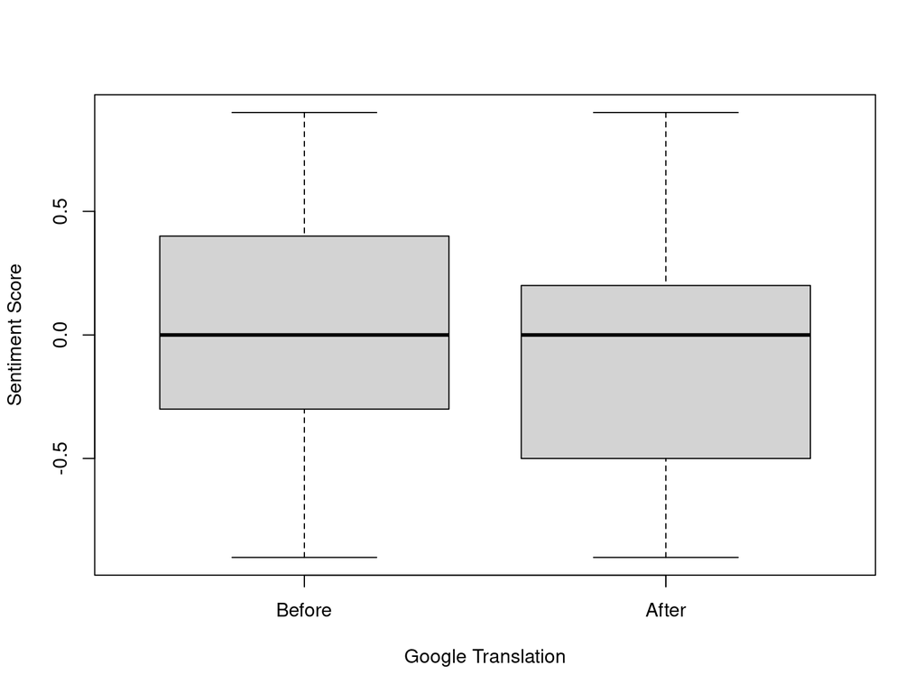

```r
boxplot(
  Google$OriginCommentsScore,
  Google$translatedDataScore,
  ylab = "Sentiment Score",
  xlab = "Google Translation"
  )
axis(1, at = 1:2, labels = c("Before", "After"))
```

- The compare of two variables in Baidu data set

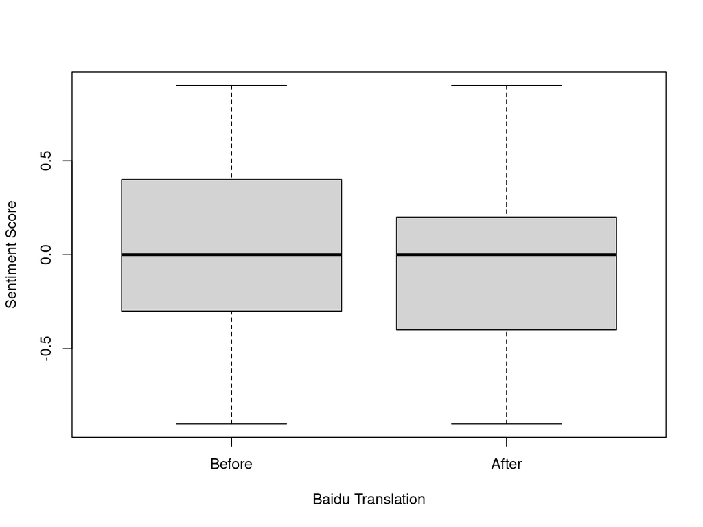

```r
boxplot(
  Baidu$OriginCommentsScore,
  Baidu$translatedDataScore,
  ylab = "Sentiment Score",
  xlab = "Baidu Translation"
  )
axis(1, at = 1:2, labels = c("Before", "After"))
```

- **before** is the original comments score, **after** is the translated data score.
- From both boxplots, we found that after translated, the value of sentiment analysis is more negative.

# Hypothesis Testing

- Perform paired t-test to analysis the data set
- We can assumed that:
  - H0 = the mean of Original Comments Score = the mean of Translated Data Score
  - H1 = the mean of Original Comments Score != the mean of Translated Data Score
- From the result, we can reject the null hypothesis(H0)

```r
# Compute t-test for google and baidu data set about original comment score and translated data score
GoogleTest <- t.test(Google$OriginCommentsScore, Google$translatedDataScore, paired = TRUE, alternative = "two.sided")
BaiduTest <- t.test(Baidu$OriginCommentsScore, Baidu$translatedDataScore, paired = TRUE, alternative = "two.sided")

GoogleTest
```

```
##
##  Paired t-test
##
## data:  Google$OriginCommentsScore and Google$translatedDataScore
## t = 66.14, df = 49407, p-value < 2.2e-16
## alternative hypothesis: true difference in means is not equal to 0
## 95 percent confidence interval:
##  0.1388970 0.1473806
## sample estimates:
## mean of the differences
##               0.1431388
```

```r
BaiduTest
```

```
##
##  Paired t-test
##
## data:  Baidu$OriginCommentsScore and Baidu$translatedDataScore
## t = 46.877, df = 49407, p-value < 2.2e-16
## alternative hypothesis: true difference in means is not equal to 0
## 95 percent confidence interval:
##  0.0977814 0.1063151
## sample estimates:
## mean of the differences
##               0.1020483
```

# Hypthesis Testing Cont.

# Google Translation tool’s heatmap

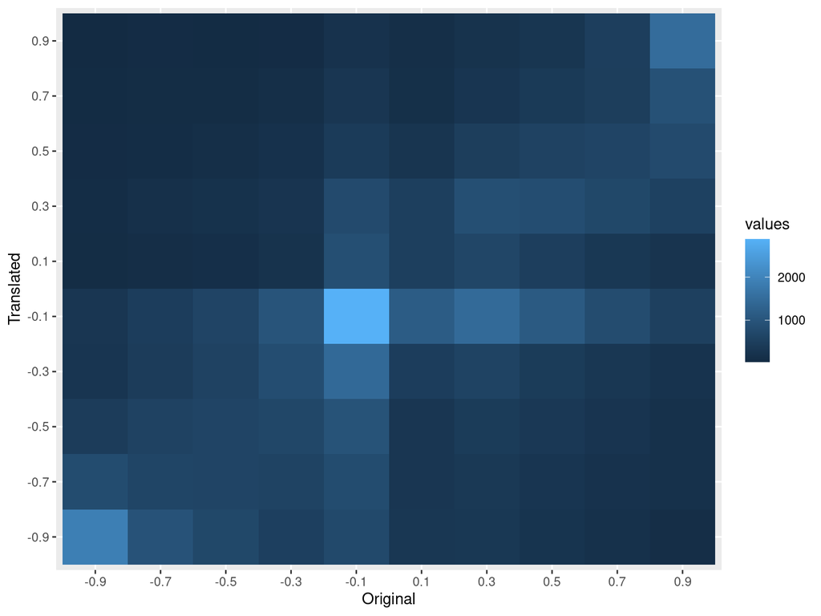

```r
plot1<-ggplot(g, aes(Original, Translated, fill= values)) +
 geom_tile()
plot1
```

```r
rm(temp)
```

# Baidu Translation tool’s heatmap

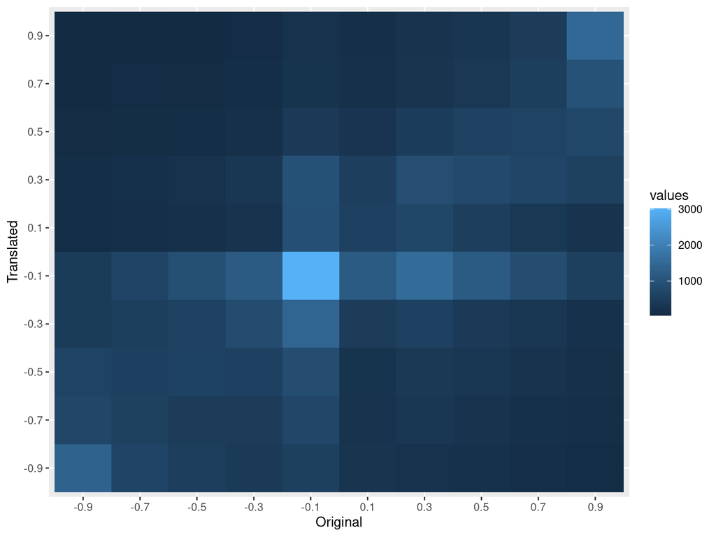

```r
plot1<-ggplot(g, aes(Original, Translated, fill= values)) +
 geom_tile()
plot1
```

```r
rm(temp)
```

# Hypthesis Testing Cont.

- From the heat map before, we can find that both Baidu and Google datasets are positive linear relationship between translated data score and original comments score (which means translated data and original comments data have positive relationship)
- So, we would like to test their correlation by Pearson correlation test.

```r
#Correlation test between original comments score and translated data score variables:

PearsonCorrelationBaidu <- cor.test(Baidu$OriginCommentsScore, Baidu$translatedDataScore, method = "pearson")
PearsonCorrelationGoogle <- cor.test(Google$OriginCommentsScore, Google$translatedDataScore, method = "pearson")
```

- Pearson Correlation about Baidu data (original comments score and translated data score)

```r
PearsonCorrelationBaidu
```

```
##
##  Pearson's product-moment correlation
##
## data:  Baidu$OriginCommentsScore and Baidu$translatedDataScore
## t = 128.42, df = 49406, p-value < 2.2e-16
## alternative hypothesis: true correlation is not equal to 0
## 95 percent confidence interval:
##  0.4936182 0.5068403
## sample estimates:
##       cor
## 0.5002584
```

- Pearson Correlation about Google data (original comments score and translated data score)

```r
PearsonCorrelationGoogle
```

```
##
##  Pearson's product-moment correlation
##
## data:  Google$OriginCommentsScore and Google$translatedDataScore
## t = 137.94, df = 49406, p-value < 2.2e-16
## alternative hypothesis: true correlation is not equal to 0
## 95 percent confidence interval:
##  0.5209076 0.5336397
## sample estimates:
##       cor
## 0.5273032
```

# Discussion

- From the t-test, we know that the translated data from Google and Baidu has significant difference from original comments data
- So, we have checked the relationship between original data and translated data by two translation tools, which are positive relationship.
- Then, we have tested the correlation by these two variables by using Pearson correlation test, and the p-values of the test for both translation tools are 2.2e-16, which is less than the significance level alpha = 0.05. So, we can conclude that translated data and original data are significantly correlated with a correlation coefficient of 0.50 for Baidu translation tool and 0.527 for Google translation tool.
- The correlation for google translation is 0.027 higher than Baidu translation, so we can say that Google translation tool is a little bit better than Baidu translation tool by translating Chinese to English.

# References

1. *Boyang Yan, Brian Yecies, Zhi Quan Zhou: Metamorphic Relations for Data Validation: A Case Study of Translated Text Messages. IEEE/ACM 4th International Workshop on Metamorphic Testing (MET ‘19), in conjunction with the 41st International Conference on Software Engineering (ICSE ‘19), Montreal, Canada; 05/2019*
2. The **Origin Movie Comments Dataset**, download from **kaggle** - https://www.kaggle.com/yanboyang713/douban-movie-comments-with-on-personal-tailor

* Contents